[figure not shown]

Contents lists available at ScienceDirect

Frontiers in Neuroendocrinology

journal homepage: www.elsevier.com/locate/yfrne

[figure not shown]

Conditioned hormonal responses: A systematic review in animals and

humans

Aleksandrina Skvortsova<sup>a</sup><sup>,</sup><sup>b</sup><sup>,</sup><sup>⁎</sup>, Dieuwke S. Veldhuijzen<sup>a</sup><sup>,</sup><sup>b</sup>, Iris E.M. Kloosterman<sup>a</sup>, Onno C. Meijer<sup>c</sup>,

Henriët van Middendorp<sup>a</sup><sup>,</sup><sup>b</sup>, Gustavo Pacheco-Lopez<sup>a</sup><sup>,</sup><sup>d</sup>, Andrea W.M. Evers<sup>a</sup><sup>,</sup><sup>b</sup><sup>,</sup><sup>e</sup>

a *Health, Medical and Neuropsychology Unit, Faculty of Social and Behavioural Sciences, Leiden University, 2333 AK Leiden, the Netherlands*

b *Leiden Institute for Brain and Cognition, 2300 RC Leiden, the Netherlands*

c *Department of Medicine, Division of Endocrinology, Leiden University Medical Center, 2333 ZA Leiden, the Netherlands*

d *Department of Health Sciences, Campus Lerma, Metropolitan Autonomous University (UAM), 52006 Lerma, Edo Mex, Mexico*

e *Department of Psychiatry, Leiden University Medical Center, 2333 ZA Leiden, the Netherlands*

A R T I C L E I N F O

*Keywords:*

Classical conditioning

Hormones

Endocrine

Associative learning

A B S T R A C T

In contrast to classical conditioning of physiological responses such as immune responses and drug effects, only a

limited number of studies investigated classical conditioning of endocrine responses. The present paper is the

first systematic review that integrates evidence from animal and human trials regarding the possibility to

condition the endocrine responses. Twenty-six animal and eight human studies were included in the review. We

demonstrated that there is accumulating evidence that classical conditioning processes are able to influence

specific endocrine responses, such as cortocosterone/cortisol and insulin, while more limited evidence exists for

other hormones. Animal and human studies were generally consistent in their findings; however, the limited

number of human studies makes it difficult to generalize and translate the results of animal research to humans.

Next to methodological recommendations for future studies, we suggest several ways how classically condi-

tioned endocrine responses can be used in clinical practice.

**1. Introduction**

Classical conditioning is a learning and memory phenomenon that

serves as a regulatory adaptive mechanism, helping to prepare the or-

ganism for recurrent changes in homeostasis, for example due to food

intake (Woods and Ramsay, 2000). Substantial research has been done

on this topic looking in various areas: from fear conditioning (e.g.,

Lissek et al., 2005; Sehlmeyer et al., 2009) to conditioning of immune

responses (e.g., Ader, 2003) and drug tolerance effects (Siegel, 1989).

Classical conditioning is a learning process where an association is

formed between a physiologically relevant stimulus (unconditioned

stimulus, US; e.g., food) and a neutral stimulus (conditioned stimulus,

CS; e.g., a sound of a bell). Initially, the biologically relevant stimulus

elicits a physiological reaction (unconditioned response, UR, e.g., sali-

vation), while the conditioned stimulus is biologically neutral and eli-

cits no response. However, after repeated contingent pairing of both

stimuli, the neutral stimulus will become a conditioned stimulus (CS)

and evoke a physiological response (conditioned response, CR; e.g.,

salivation) in the absence of the US.

Animal, and to a lesser extend human studies, have looked at the

effects of classical conditioning on the endocrine system. Hormone se-

cretion can be conceptualized as an UR to various US; for example, drug

intake. Stimuli occurring together with the US, for example the process

or environment of a drug administration, can be associated with the

hormonal responses and can become a CS.

Endocrine responses are involved in a variety of physiological pro-

cesses, from blood pressure regulation to digestion and stress respon-

siveness. Moreover, endocrine over- or underproduction underlie var-

ious diseases, such as diabetes, thyroid disease, adrenal insufficiency,

polycystic ovary syndrome and so on. Therefore, utilizing our under-

standing of endocrine conditioning to control hormone levels through

behavioral manipulation might have widespread clinical implications.

Future practice might benefit from enhancing certain endocrine reac-

tions by classical conditioning. Classical conditioning of endocrine

parameters may be one of the underlying mechanisms of placebo-con-

trolled dose reduction – a procedure in which a part of the pharma-

cological treatment is replaced by placebo while maintaining the effi-

cacy of the treatment (Rief et al., 2011). Another possible implication of

https://doi.org/10.1016/j.yfrne.2018.12.005

Received 17 September 2018; Received in revised form 21 November 2018; Accepted 21 December 2018

⁎ Corresponding author at: Health, Medical and Neuropsychology Unit, Faculty of Social and Behavioural Sciences, Leiden University, 2333 AK Leiden, the

Netherlands.

*E-mail address:* a.skvortsova@fsw.leidenuniv.nl (A. Skvortsova).

Frontiers in Neuroendocrinology 52 (2019) 206–218

Available online 25 Decem

ber 2018

0091-3022/ ©

2018 Elsevier Inc. All rights reserved.

[figure not shown]

T

conditioned endocrine responses is reduction of the nocebo effects of

medicines, unwanted treatment outcomes that are not due to the

treatment mechanism itself, as classical conditioning is hypothesized to

trigger this phenomenon (Benedetti et al., 2003). It might be possible to

prevent forming unwanted conditioned responses in the endocrine

system. For example, prior exposure to the conditioned cue or adding a

salient additional cue at the time of conditioning can prevent the de-

velopment of conditioned responses (Hall et al., 2016; Klosterhalfen

et al., 2005). In summary, there are several ways how classical con-

ditioning can be used in practice, however, a comprehensive summary

of the knowledge in this field is necessary to draw any clinical con-

clusions.

Although a few studies have summarized the findings of conditioned

endocrine responses, no systematic review covers both animal and

human studies on this topic. Several older reviews focus on animal

studies in a non-systematic manner (Stanton and Levine, 1988; Woods

and Burchfield, 1980); and two papers described human studies, with

one non-systematic report from more than a decade ago (Stockhorst,

2005) and one recent systematic review only incorporating human

studies (Tekampe et al., 2017). It currently remains unknown whether

the results of animal research can be translated to humans. The aims of

the current review are to systematically summarize the available

knowledge on conditioned endocrine responses in both animal and

human studies, to compare the results of animal and human trials, to

present an overview of the research designs used in previous studies, to

describe methodological caveats of conditioning research, and finally to

propose possible implications of using classical conditioning paradigms

in modifying hormonal responses.

**2. Methods**

*2.1. Protocol registration*

The systematic review was done following the guidelines of the

Preferred Reporting Items for Systematic Reviews and Meta-Analyses

(PRISMA) statement (Moher et al., 2009). The review protocol was

registered on PROSPERO (registration number CRD42017058783).

*2.2. Inclusion criteria*

Original experimental studies were included in which classically

conditioned hormonal responses were reported. Classically conditioned

hormonal responses were defined as hormonal changes in response to a

CS that was previously coupled with a US. The studies had to be written

in English, had to be published in a peer-reviewed journal, and had to

include a minimum of one control group. Single case studies and con-

ference abstracts were excluded. Furthermore, studies on anticipatory

hormone release (incidental learning as a response to naturally occur-

ring stimuli, such as time of the day) were excluded from this review.

The current review did not include the studies done on glucose con-

ditioning (e.g., Siegel, 1972; Woods, 1976), as glucose is not a hor-

mone. Even though it was sometimes speculated in these studies that

conditioned changes in glucose were triggered by conditioned insulin

responses, insulin was not measured directly. Also, studies on fear

conditioning were not included in this review even if they measured

corticosterone or cortisol. These studies are aimed at conditioning of

fear and hormonal responses are measured as indicators of fear and not

as a primary CR. No limitations regarding the year of publication were

set.

*2.3. Data search and study selection*

The

electronic

bibliographic

databases

PubMed,

EMBASE,

PsycINFO, and CINAHL were searched from the inception until January

2017, using the key words and connectors *endocrine* OR *hormonal* in

combination with *conditioning* OR *associative learning* OR *anticipatory*

*release* and specific names of the hormones such as for example *insulin,*

*cortisol, testosterone*. The full search terms per database are presented in

Supplementary material. The search included both human and animal

trials that measured hormonal responses to conditioned stimuli. In

addition, the search included trials on anticipatory hormone release

that will be published separately.

The search was done by two authors (A.S. and I.K.) independently.

The two authors screened the search results for eligibility based on the

titles, abstracts, and finally full texts of the reports. The results of the

search process were compared between the two authors and the final

list of the included studies was made. Classification of the studies into

intentional conditioning studies or anticipatory incidental learning

studies were done by two authors (A.S. and I.K). Studies that employed

a two-phase experimental design with acquisition and evocation phases

were labeled as intentional conditioning studies and included in the

current review. Studies that measured anticipatory hormone release by

incidental learning as a response to naturally occurring stimuli (such us

time of the day), will be included in another review and discussed

elsewhere. The inconsistencies were resolved by consulting with the

second author (D.V.).

*2.4. Data extraction and risk of bias assessment*

The data from the studies were extracted using a standardized data

extraction form. The following data were extracted from each eligible

study: first author’s name, year of publication, journal name, study

design, sample characteristics, number of acquisition sessions, number

of evocation sessions, US, UR, CS, CR, groups, hormonal outcome,

timing of outcome assessment, and main study results.

The two authors (A.S. and I.K.) assessed for risk of bias using the

Cochrane Collaboration’s tool for assessing risk of bias in human trials

(Higgins et al., 2011). For assessing risk of bias in animal studies, the

guidelines from O'Connor and Sargeant (2014) and the SYstematic

Review Centre for Laboratory animal Experimentation (SYRCLE)

(Hooijmans et al., 2014) were used. Selection bias (randomization

process and allocation concealment), performance bias (blinding of

participants and research personnel), detection bias (blinding of the

outcome assessment), attrition bias (reasons for withdrawal in all

conditions), and reporting bias (handling of missing data) were assessed

by using these guidelines. In case of inconsistencies in the assessment of

the two reviewers, the second author (D.V) was consulted. In case no

information was provided about a certain bias, unclear risk of bias was

chosen. In case the study protocol was not pre-registered, the reporting

bias was selected to be unclear as well.

**3. Results**

*3.1. Search results and studies’ characteristics*

The number of articles found on each step of the systematic search

are presented in the Flow Diagram (Fig. 1). In total 108 eligible studies

were identified of the 17,899 initially identified unique articles that

matched the search criteria; 34 of these were found eligible for inclu-

sion in the current review, whereas 74 studies will be included in a

separate review on anticipatory endocrine responses by incidental

learning. The overview of the study characteristics and study findings of

all included studies is presented in Tables 1 and 2, for animal and

human studies separately.

The vast majority of animal studies were performed in males (20 out

of 26), two studies- in females, two- in mixed groups and other two

studies did not report the gender of the animals. Half of the human

studies included only males as participants, two studies included both

males and females, and two studies only females. Three (out of 8)

human studies were performed in the same lab and written by the same

first author (Stockhorst et al., 1999, 2004, 2011). The far majority of

*A. Skvortsova et al.*

*Frontiers in Neuroendocrinology 52 (2019) 206–218*

207

*3.2. Endocrine parameters*

Most commonly measured hormones in the studies involving ani-

mals were corticosterone (in rodents) and cortisol (in other species).

Over half of animal studies (15 out of 26) measured conditioned

changes in either corticosterone or cortisol using various US. Thirteen

of these studies found significant changes in the corticosterone or cor-

tisol levels after conditioning (Ader, 1976; Barreto and Volpato, 2007;

Buske-Kirschbaum et al., 1996; Coover et al., 1977, 1980; Davis et al.,

2005; Dyck et al., 1990; Exton et al., 1995; Janz et al., 1996; Kreutz

et al., 1992; Pacheco-Lopez et al., 2004; Smotherman and Levine, 1980;

Smotherman et al., 1980), while 2 studies could not demonstrate con-

ditioned corticosterone and cortisol alterations (Janz et al., 1991;

Natelson et al., 1984). The studies reported variable conditioned

responses: increased or decreased responses were found depending on

various factors, including the US used. For example, cyclophosphamide

injection as a US (Ader, 1976) led to conditioned corticosterone in-

crease, while food as a US (Coover et al., 1977) led to a conditioned

decrease of corticosterone. Six animal studies investigated conditioned

insulin release: five of them found significant increases in insulin levels

(Detke et al., 1989; Morrell et al., 1988; Roozendaal et al., 1990;

Woods, 1972a,b; Woods et al., 1977), while one found null results

(Surwit et al., 1985). Oxytocin was investigated in two of animal trials

(Onaka and Yagi, 1998; Tancin et al., 2001) of which both found a

significant increase in conditioned oxytocin release. There were also

single studies that demonstrated conditioned release of adrenaline,

noradrenaline, and dopamine (Kassil et al., 1998), testosterone and

luteinizing hormone (Graham and Desjardins, 1980) and melatonin

(Golombek et al., 1994).

Human trials measured conditioned responses of several hormonal

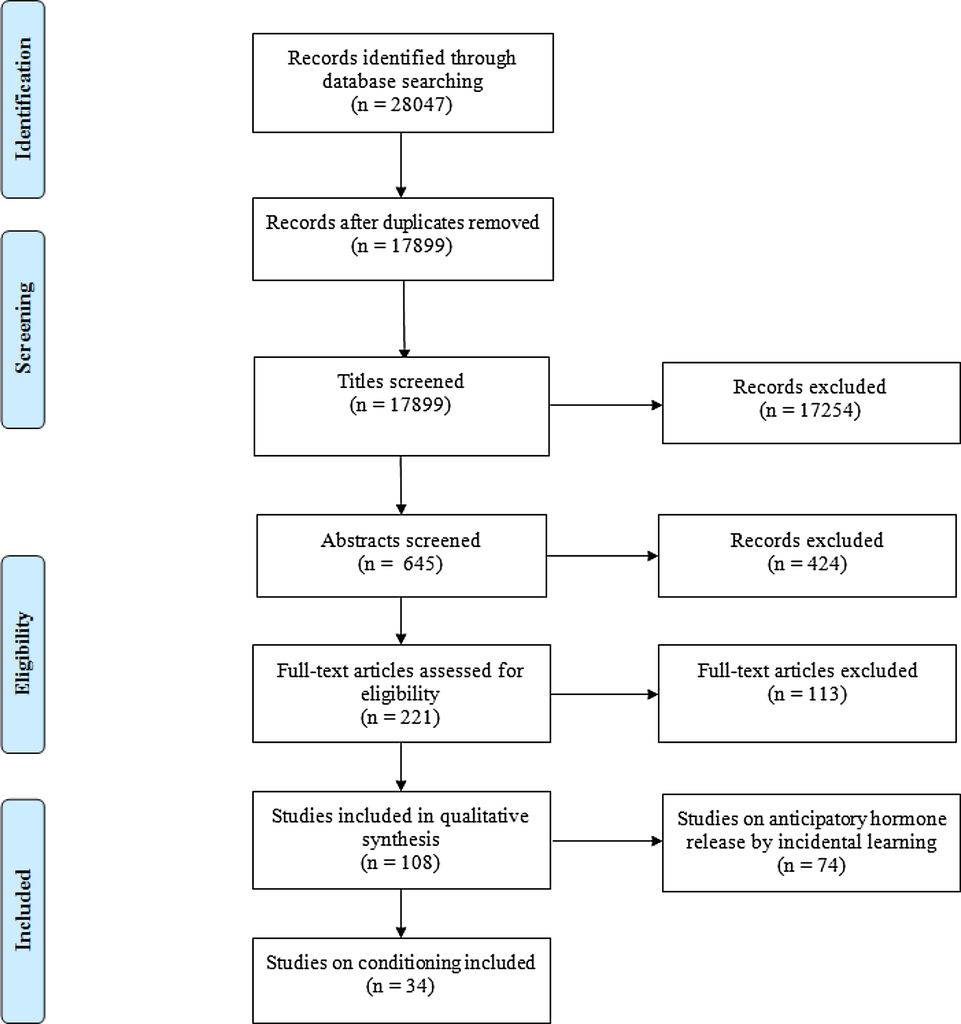

**Fig. 1.** Flow diagram with the number of included and excluded studies.

*A. Skvortsova et al.*

*Frontiers in Neuroendocrinology 52 (2019) 206–218*

208

**Table 1**

Animal studies (n = 26).

Subjects

Species (N, sex)#

Study design

Conditioned stimulus

Unconditioned stimulus

Nature, Dose, Administration

route

Conditioning protocol

Endocrine conditioned

responses

Result

Acquisition

trials

Rest days

Evocation trials

Ader, 1976;

experiment 1

rats (9–12 per

group, M)

between-subject, randomized; 10 groups:

control (nondeprived, deprived, saccharine,

cyclophosphamide), conditioned (saccharine,

H2O, deprived), nonconditioned (saccharine,

H2O, deprived)

0.1% saccharine solution

50 mg/kg cyclophosphamide

injection

1

3

2

corticosterone in

conditioned group

↑

Ader, 1976;

experiment 2

rats (55, M)

between-subject, randomized; 4 groups:

conditioned (saccharine, H2O, deprived),

nonconditioned (saccharine)

0.1% saccharine solution

50 mg/kg cyclophosphamide

injection

1

3

1

corticosterone in

conditioned group

↑

Barreto and Volpato,

2007

nile tilapia fish

(75, mixed sex)

between-subject, randomized; 5 groups:

conditioned, undisturbed control, CS only, US

control (daily US except on the final day), US

last day (daily US including the final day)

aeration off for 30 s

air emersion

10

1

1

cortisol in conditioned

group

↑

Buske-Kirschbaum

et al., 1996

rats (26, M)

between-subject, randomized; 3 groups:

conditioned, unpaired, control (saline)

peppermint odor

0.1 mg/kg nicotine bitartrate

injection

4

2

1

corticosterone

↑

Coover et al., 1977;

experiment 1

rats (60, M)

between-subject, randomized; 2 × 5 design:

food (fed, not fed) × sample time (0, 5, 10,

20, 50 min after CS)

experimenter entering the room

food

14

1

1

corticosterone in not

fed group 50 min after

CS

↓

Coover et al., 1977;

experiment 2

rats (270, M)

between-subject, randomized; 3 × 4 × 3

design: food (conditioned fed, conditioned

not fed, pseudoconditioned not fed) × trials

number (1, 6, 14, 24) × sample time (0, 10,

20 min after the CS)

placing the animal in sound

attenuating chamber

food

1, 6, 14, 24

1

1

corticosterone in

conditioned not fed 1

trial

corticosterone in

conditioned not fed 6

trials

corticosterone in

conditioned not fed

14, 24 trials

↑

n.s.

↓

Coover et al., 1977;

experiment 3

rats (120, M)

between-subject, randomized; 2 × 4 × 3

design: food (conditioned fed, conditioned

not fed, pseudoconditioned not fed) × trials

number (1, 14) × sample time (0, 10, 20 min

after the CS)

placing the animal in sound

attenuating chamber

food

1, 14

1

1

corticosterone in

conditioned not fed 1

trial

corticosterone in

conditioned not fed 14

trials

n.s.

↓

Coover et al., 1980;

experiment 1

rats (68, M)

between-subject, randomized; 2 groups: fed,

unfed

experimenter entering the room

food

14

1

1

corticosterone in

conditioned unfed

10 min after CS

corticosterone in

conditioned unfed 20

and 40 min after CS

↓

↑

Coover et al., 1980;

experiment 2

rats (92, M)

between-subject, randomized; 3 × 3 design:

surgery (operated with ventromedial

hypothalamus lesions, control operated, not

operated) × group (decapitated immediately,

fed, unfed)

placing the animal in sound

attenuating chamber

food

14

1

1

corticosterone in

operated unfed

corticosterone in

unfed 10 min after CS

n.s.

↓

Davis et al., 2005

rats (140, M)

between-subject, randomized; 2 × 2 × 2

design: sessions (5, 10) × CS (distinctive

context, home cage) × test (nicotine test,

saline test)

distinctive context room

1.0 ml/kg of body weight

nicotine bitartrate

5, 10

1

1

corticosterone in

distinctive context

group

↑

Detke et al., 1989;

rats (8, M)

within-subject, pseudo-randomized order of

trials.

long CS (A or B)- 35 sec noise;

short CS (x)- 10 sec noise. The

presentation of the US took place

on Ax but not Bx trials

1 ml of 12.5% glucose

solution

28 trials per

session, several

sessions

8 in replication

1 and 7 in

replication 2

insulin in Ax condition

↑

(*continued on next page*)

*A. Skvortsova et al.*

*Frontiers in Neuroendocrinology 52 (2019) 206–218*

209

**Table 1** (*continued*)

Subjects

Species (N, sex)#

Study design

Conditioned stimulus

Unconditioned stimulus

Nature, Dose, Administration

route

Conditioning protocol

Endocrine conditioned

responses

Result

Acquisition

trials

Rest days

Evocation trials

Dyck et al., 1990;

experiment 1

mice (30, F)

between-subject, randomized; 5 groups: IL-1,

IL-1 conditioned, IL-1 conditioned (no cues,

not re-exposed), unconditioned, negative

control

0.35% saccharine

solution + injection of LiCl

0.2–0.5 mg of recombinant

interleukin 1-beta injection

2

2

1

corticosterone in

conditioned group

↑

Dyck et al., 1990;

experiment 2

mice (50, F)

between-subject, randomized; 5 groups: IL-1,

IL-1 conditioned (saccharine + LiCl); IL-1

conditioned (saccharine), IL-1 conditioned

(no cues, not re-exposed), cue control

unconditioned

0.35% saccharine

solution + injection of LiCl

0.5 mg of recombinant

interleukin 1-beta injection

1

1

1

corticosterone in

conditioned group

↑

Dyck et al., 1990;

experiment 3

mice (27, F)

between-subject, randomized; 3 groups: IL-1

conditioned, IL-1 conditioned (no cues, not

re-exposed), negative control

peppermint odor

0.2 mg of recombinant

interleukin 1-beta injection

4

7

1

corticosterone in

conditioned group

↑

Exton et al., 1995

rats (58 first

analysis, 28

control study, M)

between-subject, randomized; 4 groups:

conditioned with saccharine, conditioned

with water, saccharine only, water only

1% saccharine solution

1 ml intraperitoneal injection

of lipopolysaccharide

1

7

1

corticosterone in

conditioned group

with saccharine

↓

Golombek et al., 1994

rats (60, M)

between-subject, randomized; 6 groups: US

for training & no treatment at the day of trial,

US for training & US for trial, CS + US for

training & CS for trial, CS + US for training &

no treatment on day of trial, CS + US for

training, CS + US for trial, CS + US for

treatment & US for trial

restricted water availability

lights off

7

1

1

pineal melatonin in

CS + US for training &

CS for trial

↑

Graham and

Desjardins, 1980;

experiment 1

rats (M)

between-subject, randomized; 5 groups: CS

followed immediately by US, CS alone, CS

followed by a 6-hour delay US, US alone,

removal from the home cage and being

handled

vapors of methyl salicylate

placing in a cage with a

sexually receptive female

14

1

1

luteinizing hormone in

conditioned group

↑

Graham and

Desjardins, 1980;

experiment 2

rats (M)

between-subject, randomized; 5 groups: CS

followed immediately by US, CS alone, CS

followed by a 6-hour delay US, US alone,

removal from the home cage and being

handled

vapors of methyl salicylate

placing in a cage with a

sexually receptive female

14

1

1

testosterone in

conditioned group

↑

Janz et al., 1991

rats (72, M)

between-subject, randomized; 5 groups:

conditioned reexposed to saccharin,

conditioned not reexposed, water followed by

IL-1 on the training day, negative control

(saline injection, and saccharin), US only

group (drug on the test)

0.1% saccharine solution

5 ng interleukin

1

1

1

corticosterone in

conditioned group

n.s.

Janz et al., 1996

rats (38, M)

between-subject, randomized; 4 groups:

paired reexposed to saccharin, paired group

not reexposed, the unpaired group received

plain water followed by an LPS injection, the

injection, cue, and water deprivation control

group received saccharin followed by a saline

injection

0.15% saccharine solution

ip injection of 50 μg

lipopolysaccharide

1

5

1

corticosterone in

conditioned group

↑

Kassil et al., 1998

rats (58, MF)

between-subject, randomized; 2 groups:

experimental (conditioning:

saccharine + rotation; test: saccharine);

control (conditioning: water + rotation; test:

saccharine)

2 ml of 0.2% saccharine solution

angular acceleration

(rotation)

1

5, 10 and

15 days

3

adrenaline,

noradrenaline,

dopamine in

conditioned group

↑

(*continued on next page*)

*A. Skvortsova et al.*

*Frontiers in Neuroendocrinology 52 (2019) 206–218*

210

**Table 1** (*continued*)

Subjects

Species (N, sex)#

Study design

Conditioned stimulus

Unconditioned stimulus

Nature, Dose, Administration

route

Conditioning protocol

Endocrine conditioned

responses

Result

Acquisition

trials

Rest days

Evocation trials

Kreutz et al., 1992

rats (11, M)

within-subject comparison:4 conditioning

trials, 4 control trials (injection of saline and

injection of Ringer solution), 2 test trials

(injection of sodium saccharine and Ringer

solution)

an intraarterial injection of

0.25 ml sodium saccharin solution

injection of 0.154 pmol

corticotrophin-releasing

factor dissolved in Ringer

solution

4

2

2

corticosterone during

test trials

↑

Morrell et al., 1988

mice (M)

between-subject, randomized; 4 groups: lean

conditioned, lean control (US and CS not

contingent), obese conditioned, obese control

(US and CS not contingent)

odor of mentholatum for 5 min

prior to feeding and 3 min during

the feeding

food

21 days and 4

additional days

1 day and

2 weeks

2

insulin in the obese

conditioned group

↑

Natelson et al., 1984

rhesus monkeys

(6, M)

within-subject; test sessions (presentation of

CS) and control sessions (no CS)

30-min tone

food

at least 1 month

daily

cortisol during test

trials

n.s.

Onaka and Yagi, 1998

rats (32, M)

between-subject, randomized; 3 groups:

conditioned, control 1 (vehicle + US),

control 2 (US + CS 2 h after)

sucrose solution (0.75–2.0 M) or

NaCl

cholecystokinin octapeptide

20 mg/kg

1

3 h

1

oxytocin in

conditioned group

↑

Pacheco-Lopez et al.,

2004

rats (32, M)

between-subject, randomized; 4 groups:

conditioned, conditioned not re-exposed,

placebo, unconditioned

0.2% saccharin solution

2.0 mg/kg staphylococcal

enterotoxin B, injection

1

6

1

corticosterone

↑

Roozendaal et al.,

1990

rats (34, M)

within-subject, time points comparison;

groups: control, central amygdala lesioned,

sham-lesioned

sound of the door opening

food

5

2

1

insulin after the CS in

sham-operated group

and control groups

↑

Smotherman and

Levine, 1980

rats (48, M)

between-subject; randomized; 6 groups:

conditioned ACTH + milk, conditioned

ACTH + water, conditioned saline + milk,

conditioned saline + water, conditioned not

injected + milk, not injected not

conditioned + milk

sweetened milk solution

ip injections of lithium

chloride (0.40 M, 7.5 ml/kg)

1

1

corticosterone in milk

conditioned groups

↑

Smotherman et al.,

1980; experiment

1

rats (37, M)

between-subject, randomized; 2 groups:

conditioned and saline

sweetened milk solution

ip injections of lithium

chloride (0.40 M, 7.5 ml/kg)

1

1

corticosterone in

conditioned group

↑

Smotherman et al.,

1980; experiment

2

rats (60, M)

between-subject; randomized; 2 × 3 design:

treatments (conditioned,

saline) × preexposures to CS (2, 5, 10)

sweetened milk solution

ip injections of lithium

chloride (0.40 M, 7.5 ml/kg)

1

1

corticosterone in

conditioned 2 and 5

preexposures groups

↑

Smotherman et al.,

1980, experiment

4

rats (60, M)

between-subject; randomized; 6 groups:

control, conditioned (with 5, 6, 7, 8, 9 or 10

preexposures)

sweetened milk solution

ip injections of lithium

chloride (0.40 M, 7.5 ml/kg)

1

1

corticosterone in

conditioned 5 and 6

preexposures groups

↑

Surwit et al., 1985

mice (24)

between-subject design, randomized; 2 × 3

design: group (obese,

control) × conditioning (conditioned, CS

without US, noncontingent CS and US)

metronome sound

shaking

7

1

1

insulin in conditioned

group

n.s.

Tancin et al., 2001

cows (20, F)

within-subject comparison: milking and

suckling in known and unknown surrounding

known surroundings

milking and suckling

oxytocin in unknown

surroundings

↓

Woods et al., 1972

rats

between-subject, randomized; 3 groups:

conditioned, control 1 (water on test trial),

control 2 (US on test trial)

smell of menthol

300 mg/kg of tolbutamide

6

1

insulin in conditioned

group

↑

Woods et al., 1977

rats (48, M)

between-subject, 6 groups: CS & US at 11:30,

US at 11:30 & CS at random, CS at 11:25 & US

at random, US & CS together but at a random

time; ad libitum food & CS at random; ad

libitum food & CS the random interval prior

to the time the appropriate meal-fed rats

received their food.

5 min of odor of mentholatum

food

21

1

1

insulin in meal fed

groups

↑

# Number of species and sex reported if this information is available; M – males; F – females; US – unconditioned stimulus, CS – conditioned stimulus.

*A. Skvortsova et al.*

*Frontiers in Neuroendocrinology 52 (2019) 206–218*

211

systems and almost all of them included measurements of several

hormones at the same time. Consistent with animal trials, most of the

human trials looked at conditioned responses of cortisol (5 out of 8).

Four of these studies found significant conditioned decreased or in-

creased cortisol levels (Benedetti et al., 2003; Hall et al., 2016; Sabbioni

et al., 1997; Stockhorst et al., 2004) and one study had null results

(Stockhorst et al., 1999). Insulin conditioning was the subject of interest

in four the human studies: 2 of these studies demonstrated conditioned

insulin increases (Stockhorst et al., 2004, 2011), while 2 found no

conditioned changes in insulin (Overduin and Jansen, 1997; Stockhorst

et al., 1999). Two human studies measured noradrenaline: one of these

demonstrated a significant conditioned increase in noradrenaline

(Stockhorst et al., 2004), while the other reported null results

(Stockhorst et al., 1999). Significant increases in growth hormone was

reported in two the studies (Benedetti et al., 2003; Stockhorst et al.,

2004). Two human studies measured glucagon and both of them failed

to find conditioned glucagon release (Stockhorst et al., 1999, 2004).

One human study demonstrated significant conditioned decreases in

adrenaline (epinephrine) (Stockhorst et al., 2011), and one study failed

to find conditioned changes in endocrine indicators of nausea (adre-

nocorticotrophic hormone, antidiuretic hormone, pancreatic polypep-

tide) (Klosterhalfen et al., 2000). In general, there were more null re-

sults found in human studies than in animal studies.

*3.3. Study designs*

The two-phase conditioning design of the studies included acquisi-

tion and evocation trials. In acquisition trials, a US that triggered cer-

tain hormonal changes (UR) was associated with an initially neutral

stimulus (becoming the CS). In the evocation trial(s), only the CS was

presented and conditioned hormonal responses (CR) were measured.

The number of acquisition and evocation trials varied across the

studies. Animal trials in general had many acquisition trials, varying

from 1 (e.g. Ader, 1976; Pacheco-Lopez et al., 2004) up to 28 (Detke

et al., 1989), while human studies had between 1 (Klosterhalfen et al.,

2000) and 6 (Overduin and Jansen, 1997; Stockhorst et al., 2011) ac-

quisition trials. In contrast, the majority of studies included only 1

evocation trial: 19 animal studies (e.g., Barreto and Volpato, 2007;

Buske-Kirschbaum et al., 1996) and 7 human studies (e.g., Benedetti

et al., 2003; Hall et al., 2016). The maximum number of evocation trials

in animal studies was 8 (Detke et al., 1989) and in human studies 6

(Stockhorst et al., 2011).

Most of the studies employed a between-subject design: 21 of an-

imal studies (e.g., Ader, 1976; Barreto and Volpato, 2007) and 7 human

studies (e.g., Benedetti et al., 2003; Klosterhalfen et al., 2000; Overduin

and Jansen, 1997). In general, animal studies included multiple control

groups, including an undisturbed control (no manipulations done)

(Barreto and Volpato, 2007), a CS only (Barreto and Volpato, 2007), a

US only (Janz et al., 1991), an unpaired (US and CS are presented in an

uncoupled manner) (Janz et al., 1996), a conditioned not re-exposed

(CS is not presented during the evocation) (Pacheco-Lopez et al., 2004),

or a placebo control group (a placebo was used instead of a US) (Dyck

et al., 1990). Most human studies (6 out of 8) included a placebo

control group (Benedetti et al., 2003; Overduin and Jansen, 1997;

Sabbioni et al., 1997; Stockhorst et al., 1999, 2004, 2011). One other

study included a control group in which the CS was given an hour

before the US (Klosterhalfen et al., 2000) and one study employed a

within-group comparison (Hall et al., 2016).

The US used to elicit hormonal changes varied between the studies.

tration of various agents including cyclophosphamide (Ader, 1976),

nicotine bitartrate (Buske-Kirschbaum et al., 1996; Davis et al., 2005),

and corticotrophin-releasing factor (Kreutz et al., 1992) were used for

the conditioning of hormone release (e.g., corticosterone).

The CS also varied across the studies. Most of the animal studies

used taste (10 out of 26) (e.g., Ader, 1976; Dyck et al., 1990), smell (6

out of 26) (e.g., Buske-Kirschbaum et al., 1996; Dyck et al., 1990), or

sound (6 out of 26) (e.g., Coover et al., 1977; Detke et al., 1989) as a CS.

In two animal studies, distinctive surroundings, such as placing animal

in an unknown room, were used as a CS (Davis et al., 2005; Tancin

et al., 2001). Single animal studies used other CS such as restricting

water availability (Golombek et al., 1994), switching off the aeration in

the fish tank (Barreto and Volpato, 2007) and intra-arterial injection of

sodium saccharin solution (Kreutz et al., 1992). Among human studies,

also smell (3 out of 8) (Stockhorst et al., 1999, 2004, 2011) and taste (2

out of 8) (Klosterhalfen et al., 2000; Sabbioni et al., 1997) were the

most commonly used CS. Single human studies used other CS: both

smell and taste (Overduin and Jansen, 1997), an injection procedure

(Benedetti et al., 2003) and an experimental context (Hall et al., 2016).

*3.4. Risk of bias assessment*

The results of the risk of bias assessment are presented in Figs. 2 and

3, for animal and human studies separately. Most animal studies lack

important information to evaluate risk of bias and were assigned an

unclear risk of bias. Human studies provide more details regarding the

procedures and, therefore, in general have lower risk of bias. The results

of the studies with the higher risk of bias did not differ from the results

of the studies with the lower risk of bias: several studies that demon-

strated null results (Janz et al., 1991; Klosterhalfen et al., 2000;

Natelson et al., 1984; Overduin and Jansen, 1997; Stockhorst et al.,

1999; Surwit et al., 1985) had the same risk of bias as other studies that

reported significant findings.

**4. Discussion**

This is the first review systematically summarizing findings of stu-

dies on intentional conditioning of the endocrine system in both ani-

mals and humans. Findings of classical conditioning studies using a

two-phase design incorporating acquisition and evocation trials were

systematically reviewed. This review demonstrates that there is an ac-

cumulating evidence from both animal and human studies that classical

conditioning processes are able to influence specific endocrine re-

sponses. Some endocrine responses have been more thoroughly studied,

such as corticosterone/cortisol and insulin, while fewer studies looked

at other hormones, such as testosterone, luteinizing hormone, oxytocin,

growth hormone, glucagon and melatonin, adrenaline, and nora-

drenaline. Most notably, animal and human studies were generally

consistent in their findings: conditioned responses were found in the

same endocrine systems in both animal and human trials. Nevertheless,

some methodological caveats exist that need attention in future re-

search.

The present review demonstrated that not all endocrine systems

were investigated equally in the context of classical conditioning. The

majority of the studies focused on hypothalamus-pituitaryadrenal axis

and on insulin responses, while evidence for other hormones is very

limited or absent. Future studies should focus on other endocrine

parameters, especially those that play a possible role in the treatment of

diseases, such as thyroid hormone, growth hormone, prolactin, adre-

nocorticotropic hormone etc.

Additionally, the majority of the studies were performed in males

and none of them looked at the possible moderation of the conditioned

response by gender. So far there is no evidence that gender moderates

placebo effects (Weimer et al., 2015). Nevertheless, considering the

gender specificity of the endocrine responses, future research should

examine possible differences in endocrine conditioning between males

and females.

We have also documented that the results of the animal studies are

more extensive than the results of the human studies and most of the

animal studies found coherent conditioned endocrine responses. The

*A. Skvortsova et al.*

*Frontiers in Neuroendocrinology 52 (2019) 206–218*

212

**Table 2**

Human studies (n = 8).

Authors, year of

publication

Subjects

N (sex)#

Study design

Conditioned stimulus

Unconditioned stimulus

Nature, Dose, Administration

route

Conditioning protocol

Endocrine conditioned responses

Result

Acquisition

trials

Rest days

Evocation

trials

Benedetti et al.,

2003

95 (47 M,

48F)

between- subject, randomized; 9 groups:

conditioned and control groups with

various suggestions

injection procedure

sumatriptan injection

2

1

1

growth hormone levels in the

conditioned groups

cortisol levels in the conditioned

groups

↑

↓

Hall et al., 2016

32 (F)

within-group comparison for cortisol, 4

conditioned groups: latent inhibition with

overshadowing, latent inhibition,

overshadowing, control

context of rotation

rotation

2

1

1

cortisol after the CS presentation in all

groups

↑

Klosterhalfen

et al., 2000

90 (42 M,

48F)

between-subject, randomized; 2 groups:

conditioned, control (CS 1 h before US)

100 ml elder-berry juice

rotation procedure

1

7

1

adrenocorticotrophic hormone,

antidiuretic hormone, pancreatic

polypeptide in conditioned group

n.s.

Overduin and

Jansen, 1997

20 (F)

between-group, randomized; 2 groups:

conditioned, placebo

peppermint flavor

50 g ad lib glucose

6

2

1

insulin levels in conditioned group

n.s.

Sabbioni et al.,

1997

25 (M)

between-subject, randomized; 2 groups:

conditioned, placebo

lemon-lime with bitter tonic

beverage

5 ml dexamethasone ad lib

3

7

1

plasma cortisol levels in conditioned

group

↑

Stockhorst et al.,

1999

20 (M)

between- subject, randomized; 2 groups:

conditioned, placebo

rosewood–peppermint oil

smell

intravenous insulin injection

(0.035 units/kg)

4

1

1

insulin in conditioned group

glucagon in conditioned group

noradrenaline in conditioned group

cortisol in conditioned group

n.s.

n.s.

n.s.

n.s.

Stockhorst et al.,

2004

30 (M)

between-subject, randomized; 3 groups:

insulin conditioned, glucose conditioned,

placebo

rosewood-peppermint oil

smell

intravenous insulin injection

(0.05 IU/kg) or intravenous

glucose injection (15%, 0.5 g/

kg)

4

2

1

cortisol, insulin in the glucose

conditioned group

glucagon in the glucose conditioned

group

noradrenaline, growth hormone in the

insulin conditioned group

↑

n.s.

↑

Stockhorst et al.,

2011

32 (M)

between-subject, randomized; 2 groups:

conditioned, placebo

smell of meta-cresol

soluble H-insulin intranasal

spray (20U[0.2 ml])

6

1

6

peripheral insulin in conditioned group

epinephrine in conditioned group

↑

↓

# Number of species and sex reported if this information is available; M – males; F – females; US – unconditioned stimulus, CS – conditioned stimulus.

*A. Skvortsova et al.*

*Frontiers in Neuroendocrinology 52 (2019) 206–218*

213

reviewed here found conditioned cortisol changes and since the review

search was done, one newly appeared study failed to condition the

cortisol response in humans (Petrakova et al., 2017). Also conditioning

of insulin responses was less successful in human studies compared to

animal studies. Possibly, conditionability of insulin responses in hu-

mans depends more on the US Stockhorst et al. (2011) demonstrated

that it is possible to condition insulin release using intranasal insulin

spray as a US, but not when using an intravenous insulin injection

(Stockhorst et al., 1999). Another difference between animal and

human research that might lead to different findings, is the number of

acquisition trials. Animal studies in general have more acquisition trials

than human studies. Possibly, a low number of acquisition trials in

human research might lead to more contradictory results, as a small

number of acquisition trials might not always be enough to establish the

association between the US and the CS.

In general, the limited number of human studies makes it difficult to

generalize the results of the animal research to humans. Several

methodological limitations exist that complicate human endocrine

conditioning experiments. First of all, application of a two-phase design

is time consuming, since it implies several sessions with the adminis-

tration of pharmacological agents and acquiring biological samples,

which is done easier in animals than in humans. Moreover, the en-

vironment in animal studies is more controllable in comparison to

human studies. Various factors that are difficult to strictly control in

humans over a period of time, such as food consumption, physical ac-

tivity, and psychogenic stressors, can confound human research, po-

tentially creating noise in the outcomes. Finally, cognitions and ex-

pectations might play an additional role in the conditioned hormone

release in humans. Although Benedetti et al. (2003) showed that giving

verbal suggestions regarding the change of cortisol and growth hor-

mone levels did not influence the secretion of these hormones, other

studies with an experimental classical conditioning design did not take

the expectations of the participants in consideration. Presentation of the

CS can trigger cognitive expectations that have to be taken into account

while interpreting the results. For future research, it is important to

further identify the role of expectancies and cognitions in the classically

conditioned hormone release, because these can be possibly manipu-

lated in clinical practice.

It is also important to point out that there was no consistency in the

reviewed studies regarding the exact study design or procedures that

were used to condition endocrine responses. Different number of ac-

quisition and evocation trials were used in different studies. To date it is

unclear what number of acquisition trials is optimal to develop condi-

tioned responses in the endocrine system, and whether this is depen-

dent on the species that is being examined, the conditioned drug of

interest, or other factors such as the context of conditioning. Only two

studies included in this review compared the effectiveness of different

numbers of acquisition trials in eliciting conditioned endocrine re-

sponses and both of them concerned conditioned corticosterone. Coover

et al. (1977) showed that conditioned corticosterone decreased in

response to a CS associated with feeding after 14 acquisition trials, but

that 6 trials were not enough to demonstrate this response. Davis et al.

(2005) demonstrated that conditioned corticosterone release already

developed after 5 pairing of nicotine bitartrate with a distinctive con-

text and this release increased marginally after 10 acquisition trials.

These results are generally in line with the research on conditioned

immune responses that demonstrated that more acquisition trials may

lead to a stronger conditioned response (Barrett et al., 2000), however

more research in the endocrine system is needed to confirm this pro-

position in relation to the nature and intensity of the US. The number of

evocation trials was significantly lower than the number of acquisition

trials: the majority of studies used only 1 evocation trial to test whether

conditioning took place. This general use of only 1 evocation trial

makes it unfortunately impossible to study the extinction process in the

endocrine system, since more evocation trials are needed to see how

fast the classically conditioned endocrine responses disappear.

A wide variety was found regarding the different types of the CS that

were used in the different studies. Most of the animal and human trials

used either gustatory (e.g.: Buske-Kirschbaum et al., 1992; Sabbioni

et al., 1997) or olfactory (e.g.: Overduin and Jansen, 1997; Stockhorst

et al., 2004) conditioned stimuli. It was previously reported that gus-

tatory and olfactory CS associate with visceral US stronger than other

types of CS (Domjan, 1973, 2005; Pacheco-Lopez et al., 2007). This can

be explained by the naturalistic association and biological importance

of such stimuli, because they are associated with food intake and are

important for survival. However, other types of CS were also employed

in a few studies and were successfully associated with endocrine

changes. For example, Benedetti et al. (2003) used an injection proce-

dure as a CS to condition changes in cortisol. Speculatively, the nature

of the CS seems of marginal significance since conditioned effects were

found with both biologically relevant and other types of CS, but future

studies may investigate this further and compare the efficiency of

various CSs.

Finally, only one of the reviewed studies looked into the neuronal

mechanisms of the conditioned endocrine responses. Roozendaal et al.

(1990) demonstrated that the central nucleus of the amygdala was in-

volved in the conditioned insulin release and its lesioning abolished this

conditioned response in rats. The most well-investigated neural path-

ways of conditioning are the mechanisms involved in the conditioning

of pain responses: it was demonstrated that the descending pain control

system gets activated during placebo analgesia (Eippert et al., 2009).

Possibly, these findings can be extended to endocrine conditioning in

that brain regions responsible for endocrine regulation are also re-

sponsible for the release of hormones during conditioning. Never-

theless, this remains only a speculation and future research should focus

on further identifying the neural pathways that underlie conditioned

endocrine responses in both animals and humans.

The main limitation of this review is heterogeneity of the included

studies that makes it difficult to compare them and make definitive

conclusions. There is no standard conditioning design established and,

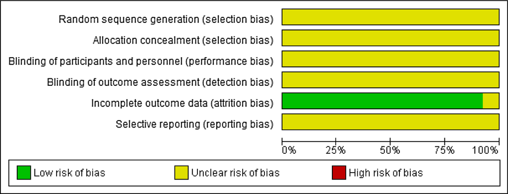

**Fig. 2.** Risk of bias for animal studies. Risk of bias is presented as a percentage across all included studies and for each separate study.

*A. Skvortsova et al.*

*Frontiers in Neuroendocrinology 52 (2019) 206–218*

214

therefore, every experiment recruited a different procedure for the

conditioning of endocrine responses. In case of null results, such

variability in procedures makes it difficult to conclude whether the

failure to find conditioned responses was caused by an unappropriated

experimental design or by the fact that the certain endocrine system is

not malleable to conditioning.

Several methodological aspects of the present review have to be

mentioned. The review has not included studies on anticipatory hor-

mone release induced by incidental learning: that is considered to be a

conditioned response to naturally occurring conditioned stimuli such as

a particular time of the day, called “Zeitgeber” (Ehlers et al., 1988).

Incidental classical conditioning in this case is established naturally

already before the start of the experiment, as for example, increase in

insulin levels in response to a food taste without the food ingestion

(e.g., Berthoud et al., 1981). Instead, in this review we focused on in-

tentional conditioning studies that included acquisition and evocation

phases and established a connection between initially neutral stimulus

and an US. Additionally, the present review did not include glucose

conditioning studies (e.g., Siegel, 1972; Woods, 1976) even though

conditioned changes in glucose levels might indicate conditioned in-

sulin response. This link between conditioned insulin and glucose re-

sponses not always seem to exist, as for example, Stockhorst et al.

(1999) found a conditioned glucose decrease during conditioning with

intravenous insulin but no conditioned changes in insulin levels. As it is

not possible to prove that conditioned changes in glucose are triggered

by conditioned insulin response, studies that measured only glucose –

and therefore no hormonal outcomes – were not included in this re-

view.

This review shows promising results for applying mechanisms of

classical conditioning in clinical practice. For instance, it was demon-

strated that cortisol levels can be increased (Sabbioni et al., 1997) using

the classical conditioning procedures. Administration of cortisone (a

prodrug of cortisol) can have fear-reducing effects in phobic patients

(Soravia et al., 2006) and might prevent the occurrence or reduce the

severity of post-traumatic stress disorder after a traumatic event (Amos

et al., 2014). Therefore, speculatively, using the classical conditioning

procedure to elicit endogenous cortisol release might be beneficial for

these groups of patients. Another clinically relevant example could be

applying classical conditioning of insulin responses as demonstrated by

Stockhorst et al (2011) in healthy control subjects to patients with

diabetes type-2 who suffer from dysfunctional insulin system and

heightened glucose levels.

Also, placebo-controlled dose reduction is based on the principles of

classical conditioning (Rief et al., 2011). It was demonstrated that

placebo-controlled dose reduction can be as efficient as full treatment

for ADHD and psoriasis (Ader et al., 2010; Sandler et al., 2010). Al-

though these two studies did not measure endocrine parameters and the

mechanisms of the symptoms reduction remain therefore unclear, it

might be possible that the classical conditioning procedure triggered

endocrine changes that lead to the reduction of symptoms.

Finally, unwanted side effects of medications, nocebo effects, can be

triggered by classically conditioned endocrine and other pharmacolo-

gical responses (Benedetti et al., 2003). For example, Hall et al. (2016)

showed that nausea as well as cortisol release can be simultaneously

classically conditioned and that there effects can be diminished using

overshadowing (presentation of a salient additional cue at the time of

conditioning). This principle could be applied to other unwanted side

effects, for example, nausea caused by chemotherapy in cancer patients,

that has been proposed to be triggered by classical conditioning and

shown to be related to heightened cortisol levels (Stockhorst et al.,

1998). Presenting a salient cue such as a distinctive drink along with

chemotherapy, might decrease the conditioned nausea and cortisol le-

vels. It would be also worthwhile for future studies to look into possi-

bilities of using overshadowing for the modification of other endocrine

conditioned responses.

Overall, despite the heterogeneity of the described studies, this

systematic review delivers supportive evidence that endocrine levels

can be influenced by classical conditioning mechanisms, at least for

certain endocrine parameters (e.g., insulin and cortisol) in animal stu-

dies and to a lesser extent in human studies. Nevertheless, to be able to

use classical conditioning in clinical practice, several concrete questions

still have to be answered by future research. First, it is important to

investigate if all hormones can be influenced by conditioning and how

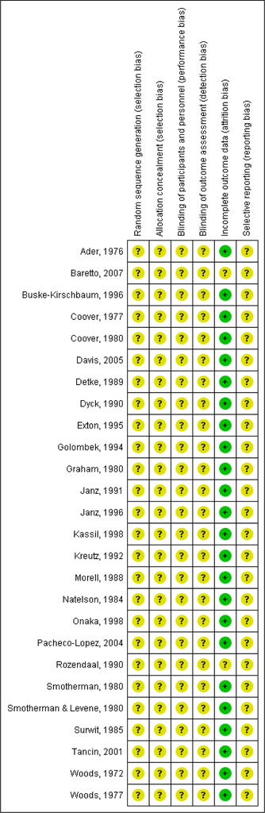

**Fig. 2.** (*continued*)

*A. Skvortsova et al.*

*Frontiers in Neuroendocrinology 52 (2019) 206–218*

215

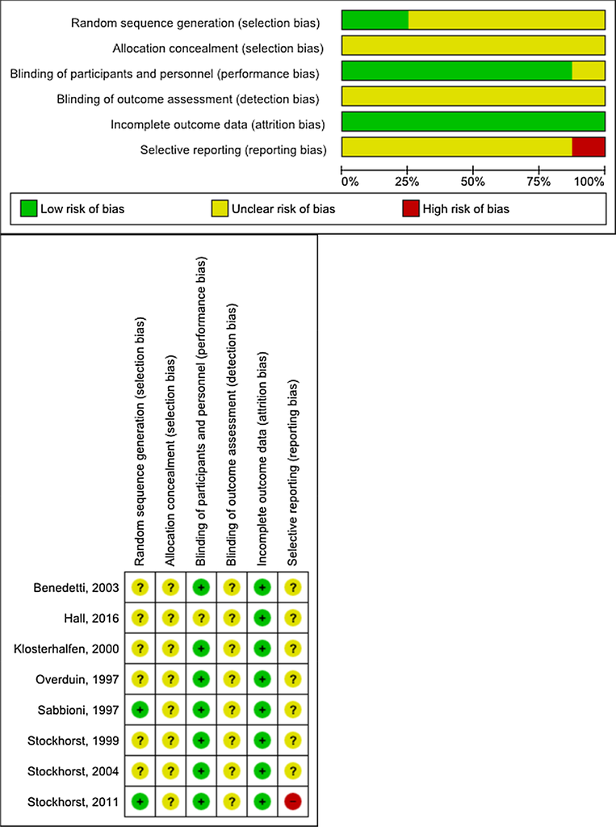

**Fig. 3.** Risk of bias for human studies. Risk of bias is presented as a percentage across all included studies and for each separate study.

*A. Skvortsova et al.*

*Frontiers in Neuroendocrinology 52 (2019) 206–218*

216

conditioned hormone responses generalize to the other hormonal and

immune parameters. Second, more insight is needed in the extinction of

the conditioned hormonal responses and the optimal way to reinforce

them. Moreover, individual differences and possible predictors of en-

docrine responses remain underexplored. Finally, more knowledge is

needed about how the conditioned responses influence various health

outcomes and behavior. It is important that laboratory studies focus on

investigating classical conditioning phenomena in various hormonal

systems and use controlled designs of high methodological quality.

Clinical trials may further explore the possibilities of applying the

conditioning paradigms in clinical settings for dose reductions, en-

hancements of treatment favorable endocrine parameters, and reduc-

tion of unfavorable conditioned endocrine responses.

**Conflict of interest**

None.

**Funding**

This work was supported by the European Research Council

Consolidator Grant (ERC-2013-CoG-617700, granted to A. Evers).

**Appendix A. Supplementary material**

Supplementary data to this article can be found online at https://

doi.org/10.1016/j.yfrne.2018.12.005.

**References**

Ader, R., 1976. Conditioned adrenocortical steroid elevations in the rat. J. Comp. Physiol.

Psychol. 90, 1156–1163. https://doi.org/10.1037/h0077290.

Ader, R., 2003. Conditioned immunomodulation: research needs and directions. Brain

Behav. Immun. 17 (1), 51–57. https://doi.org/10.1016/s0889-1591(02)00067-3.

Ader, R., Mercurio, M.G., Walton, J., James, D., Davis, M., Ojha, V., et al., 2010.

Conditioned pharmacotherapeutic effects: a preliminary study. Psychosom. Med. 72

(2), 192. https://doi.org/10.1097/psy.0b013e3181cbd38b.

Amos, T., Stein, D.J., Ipser, J.C., 2014. Pharmacological interventions for preventing post-

traumatic stress disorder (PTSD). The Cochrane Library. https://doi.org/10.1002/

14651858.cd006239.pub2.

Barrett, J.E., King, M.G., Pang, G., 2000. Conditioning rhinitis in allergic humans. Ann.

NY Acad. Sci. 917 (1), 853–859. https://doi.org/10.1111/j.1749-6632.2000.

tb05451.x.

Barreto, R.E., Volpato, G.L., 2007. Evaluating feeding as unconditioned stimulus for

conditioning of an endocrine effect in Nile tilapia. Physiol. Behav. 92, 867–872.

https://doi.org/10.1016/j.physbeh.2007.06.013.

Benedetti, F., Pollo, A., Lopiano, L., Lanotte, M., Vighetti, S., Rainero, I., 2003. Conscious

expectation and unconscious conditioning in analgesic, motor, and hormonal pla-

cebo/nocebo responses. J. Neurosci. 23 (10), 4315–4323. https://doi.org/10.1523/

jneurosci.23-10-04315.2003.

Berthoud, H.R., Bereiter, D.A., Trimble, E.R., Siegel, E.G., Jeanrenaud, B., 1981. Cephalic

phase, reflex insulin secretion neuroanatomical and physiological characterization.

Diabetologia 20 (3), 393–401. https://doi.org/10.1007/bf00254508.

Buske-Kirschbaum, A., Grota, L., Kirschbaum, C., Bienen, T., Moynihan, J., Ader, R., Blair,

M.L., Hellhammer, D.H., Felten, D.L., 1996. Conditioned increase in peripheral blood

mononuclear cell (PBMC) number and corticosterone secretion in the rat. Pharmacol.

Biochem. Behav. 55 (1), 27–32.

Buske-Kirschbaum, A., Kirschbaum, C., Stierle, H., Lehnert, H., Hellhammer, D., 1992.

Conditioned increase of natural killer cell activity (NKCA) in humans. Psychosom.

Med. 54 (2), 123–132. https://doi.org/10.1097/00006842-199203000-00001.

Coover, G.D., Sutton, B.R., Heybach, J.P., 1977. Conditioning decreases in plasma cor-

ticosterone level in rats by pairing stimuli with daily feedings. J. Comp. Physiol.

Psychol. 91, 716–726. https://doi.org/10.1037/h0077363.

Coover, G.D., Welle, S., Hart, R.P., 1980. Effects of eating, meal cues and ventromedial

hypothalamic lesions on serum corticosterone, glucose and free fatty acid con-

centrations. Physiol. Behav. 25, 641–651. https://doi.org/10.1016/0031-9384(80)

90366-2.

Davis, K.W., Cepeda-Benito, A., Harraid, J.H., Wellman, P.J., 2005. Plasma corticosterone

in the rat in response to nicotine and saline injections in a context previously paired

or unpaired with nicotine. Psychopharmacology 180, 466–472. https://doi.org/10.

1007/s00213-005-2185-7.

Detke, M.J., Brandon, S.E., Weingarten, H.P., Rodin, J., Wagner, A.R., 1989. Modulation

of behavioral and insulin responses by contextual stimuli paired with food. Physiol.

Behav. 45, 845–851. https://doi.org/10.1016/0031-9384(89)90305-3.

Domjan, M., 1973. Role of ingestion in odor-toxicosis learning in the rat. J. Comp.

Physiol. Psychol. 84 (3), 507. https://doi.org/10.1037/h0034878.

Domjan, M., 2005. Pavlovian conditioning: a functional perspective. Annu. Rev. Psychol.

56, 179–206. https://doi.org/10.1146/annurev.psych.55.090902.141409.

Dyck, D.G., Janz, L., Osachuk, T.A.G., Falk, J., Labinsky, J., Greenberg, A.H., 1990. The

pavlovian conditioning of IL-1-induced glucocorticoid secretion. Brain Behav.

Immun. 4, 93–104. https://doi.org/10.1016/0889-1591(90)90012-f.

Ehlers, C.L., Frank, E., Kupfer, D.J., 1988. Social zeitgebers and biological rhythms: a

unified approach to understanding the etiology of depression. Arch. Gen. Psychiatry

45 (10), 948–952. https://doi.org/10.1001/archpsyc.1988.01800340076012.

Eippert, F., Bingel, U., Schoell, E.D., Yacubian, J., Klinger, R., Lorenz, J., Buchel, C., 2009.

Activaton of the opiodergic descending pain control system underlies placebo an-

algesia. Neuron 63 (4), 533–543.

Exton, M.S., Bull, D.F., King, M.G., Husband, A.J., 1995. Paradoxical conditioning of the

plasma copper and corticosterone responses to bacterial endotoxin. Pharmacol.

Biochem. Behav. 52, 347–354. https://doi.org/10.1016/0091-3057(95)00109-a.

Golombek, D., Chuluyan, H., Kanterewicz, B., Cardinali, D., 1994. Increased pineal

melatonin content coupled to restricted water availability in a Pavlovian conditioning

paradigm in rats. J. Neural Transm. 98 (3), 237–246. https://doi.org/10.1007/

bf01276539.

Graham, J.M., Desjardins, C., 1980. Classical conditioning: induction of luteinizing hor-

mone and testosterone secretion in anticipation of sexual activity. Science 210,

1039–1041. https://doi.org/10.1126/science.7434016.

Hall, G., Stockhorst, U., Enck, P., Klosterhalfen, S., 2016. Overshadowing and latent in-

hibition in nausea-based context conditioning in humans: theoretical and practical

implications. Q. J. Exp. Psychol. 1–12. https://doi.org/10.1080/17470218.2015.

1080739.

Higgins, J.P., Altman, D.G., Gøtzsche, P.C., Jüni, P., Moher, D., Oxman, A.D., Savović, J.,

Schulz, K.F., Weeks, L., Sterne, J.A., 2011. The Cochrane Collaboration’s tool for

assessing risk of bias in randomised trials. BMJ 343, d5928. https://doi.org/10.1136/

bmj.d5928.

Hooijmans, C.R., Leenaars, M., Rovers, M.M., Ritskes-Hoitinga, M., Langendam, M.W., de

Vries, R.B., 2014. SYRCLE’s risk of bias tool for animal studies. BMC Med. Res.

Methodol. 14, 43. https://doi.org/10.1186/1471-2288-14-43.

Janz, L., Brown, R., Zuo, L., Falk, J., Greenberg, A., Dyck, D., 1991. Conditioned taste

aversion but not adrenal activity develops to ICV adminstration of interleukin-1 in

rats. Physiol. Behav. 49, 691–694. https://doi.org/10.1016/0031-9384(91)90303-6.

Janz, L.J., Green-Johnson, J., Murray, L., Vriend, C.Y., Nance, D.M., Greenberg, A.H.,

Dyck, D.G., 1996. Pavlovian conditioning of LPS-induced responses: effects on cor-

ticosterone, splenic NE, and IL-2 production. Physiol. Behav. 59, 1103–1109. https://

doi.org/10.1016/0031-9384(95)02171-x.

Kassil, V.G., Bondarenko, M.Y., Mikhailenko, V.A., 1998. Conditioned reflex responses of

the sympathetico-adrenal system to an aversive taste stimulus. Neurosci. Behav.

Physiol. 28, 31–37. https://doi.org/10.1007/bf02461909.

Klosterhalfen, S., Kellermann, S., Stockhorst, U., Wolf, J., Kirschbaum, C., Hall, G., Enck,

P., 2005. Latent inhibition of rotation chair-induced nausea in healthy male and fe-

male volunteers. Psychosom. Med. 67 (2), 335–340.

Klosterhalfen, S., Ruttgers, A., Krumrey, E., Otto, B., Stockhorst, U., Riepl, R.L., Probst, T.,

Enck, P., 2000. Pavlovian conditioning of taste aversion using a motion sickness

paradigm. Psychosom. Med. 62, 671–677.

Kreutz, M., Hellhammer, D., Murison, R., Vetter, H., Krause, U., Lehnert, H., 1992.

Pavlovian conditioning of corticotropin-releasing factor-induced increase of blood

pressure and corticosterone secretion in the rat. Acta Physiol. Scand. 145, 59–63.

https://doi.org/10.1097/01.psy.0000156930.00201.e0.

Lissek, S., Powers, A.S., McClure, E.B., Phelps, E.A., Woldehawariat, G., Grillon, C., Pine,

D.S., 2005. Classical fear conditioning in the anxiety disorders: a meta-analysis.

Behav. Res. Ther. 43 (11), 1391–1424. https://doi.org/10.1016/j.brat.2004.10.007.

Moher, D., Liberati, A., Tetzlaff, J., Altman, D.G., PRISMA Group, 2009. Preferred re-

porting items for systematic reviews and meta-analyses: the PRISMA statement. PLoS

Med. 6 (7), e1000097. https://doi.org/10.1371/journal.pmed.1000097.

Morrell, E.M., Surwit, R.S., Kuhn, C.M., Feinglos, M.N., Cochrane, C., 1988. Classically

conditioned enhancement of hyperinsulinemia in the ob/ob mouse. Psychosom. Med.

50, 586–590. https://doi.org/10.1097/00006842-198811000-00004.

Natelson, B.H., Stokes, P.E., Tapp, W.N., 1984. Plasma cortisol and appetitively motivated

arousal in monkeys. Behav. Neurosci. 98, 925–929. https://doi.org/10.1037//0735-

7044.98.5.925.

O'Connor, A.M., Sargeant, J.M., 2014. Critical appraisal of studies using laboratory an-

imal models. ILAR J. 55, 405–417. https://doi.org/10.1037//0735-7044.98.5.925.

Onaka, T., Yagi, K., 1998. Oxytocin release from the neurohypophysis after the taste

stimuli previously paired with intravenous cholecystokinin in anaesthetized rats. J.

Neuroendocrinol. 10, 309–316. https://doi.org/10.1046/j.1365-2826.1998.00209.x.

Overduin, J., Jansen, A., 1997. Conditioned insulin and blood sugar responses in humans

in relation to binge eating. Physiol. Behav. 61, 569–575. https://doi.org/10.1016/

s0031-9384(96)00504-5.

Pacheco-Lopez, G., Niemi, M.-B., Engler, H., Schedlowski, M., 2007. Behaviorally con-

ditioned enhancement of immune responses: the portrait of conditioned immune

responses might be the bizarre reflection of neural activity. In: Ader, A. (Ed.),

Psychoimmunology. Academic Press, New York, pp. 591–616. https://doi.org/10.

1016/b978-012088576-3/50036-8.

Pacheco-Lopez, G., Niemi, M.-B., Kou, W., Härting, M., Del Rey, A., Besedovsky, H.,

Schedlowski, M., 2004. Behavioural endocrine immune-conditioned response is in-

duced by taste and superantigen pairing. Neuroscience 129, 555–562. https://doi.

org/10.1016/j.neuroscience.2004.08.033.

Petrakova, L., Boy, K., Kügler, M., Benson, S., Engler, H., Möller, L., Schedlowski, M.,

2017. Plasma cortisol response cannot be classically conditioned in a taste-endocrine

paradigm in humans. Psychopharmacology 234 (21), 3249–3257. https://doi.org/10.

1007/s00213-017-4718-2.

Roozendaal, B., Oldenburger, W.P., Strubbe, J.H., Koolhaas, J.M., Bohus, B., 1990. The

*A. Skvortsova et al.*

*Frontiers in Neuroendocrinology 52 (2019) 206–218*

217

central amygdala is involved in the conditioned but not in the meal-induced cephalic

insulin response in the rat. Neurosci. Lett. 116, 210–215. https://doi.org/10.1016/

0304-3940(90)90412-3.

Rief, W., Bingel, U., Schedlowski, M., Enck, P., 2011. Mechanisms involved in placebo

and nocebo responses and implications for drug trials. Clin. Pharmacol. Ther. 90 (5),

722–726. https://doi.org/10.1038/clpt.2011.204.

Sabbioni, M.E.E., Bovbjerg, D.H., Mathew, S., Sikes, C., Lasley, B., Stokes, P.E., 1997.

Classically conditioned changes in plasma cortisol levels induced by dexamethasone

in healthy men. FASEB J. 11, 1291–1296. https://doi.org/10.1096/fasebj.11.14.

9409548.

Sandler, A.D., Glesne, C.E., Bodfish, J.W., 2010. Conditioned placebo dose reduction: a

new treatment in ADHD? J. Dev. Behav. Pediatr. 31 (5), 369. https://doi.org/10.

1097/dbp.0b013e3181e121ed.

Sehlmeyer, C., Schöning, S., Zwitserlood, P., Pfleiderer, B., Kircher, T., Arolt, V., Konrad,

C., 2009. Human fear conditioning and extinction in neuroimaging: a systematic

review. PloS One 4 (6), e5865. https://doi.org/10.1371/journal.pone.0005865.

Siegel, S., 1972. Conditioning of insulin-induced glycemia. J. Comp. Physiol. Psychol. 78,

233–241. https://doi.org/10.1037/h0032180.

Siegel, S., 1989. Pharmacological conditioning and drug effects. In: Goudie, A.J., Emmett-

Oglesby, M.W. (Eds.), Psychoactive Drugs. Contemporary Neuroscience. Humana

Press, Totowa, NJ, pp. 115–180. https://doi.org/10.1007/978-1-59259-464-1_3.

Smotherman, W.P., Levine, S., 1980. ACTH4-10 affects behavior but not plasma corti-

costerone levels in a conditioned taste aversion situation. Peptides 1, 207–210.

https://doi.org/10.1016/0196-9781(80)90055-8.

Smotherman, W.P., Margolis, A., Levine, S., 1980. Flavor preexposures in a conditioned

taste aversion situation: a dissociation of behavioral and endocrine effects in rats. J.

Comp. Physiol. Psychol. 94, 25–35. https://doi.org/10.1037/h0077643.

Soravia, L.M., Heinrichs, M., Aerni, A., Maroni, C., Schelling, G., Ehlert, U., Roozendaal,

B., Dominique, J.F., 2006. Glucocorticoids reduce phobic fear in humans. Proc. Natl.

Acad. Sci. U.S.A. 103 (14), 5585–5590. https://doi.org/10.1073/pnas.0509184103.

Stanton, M.E., Levine, S., 1988. Pavlovian conditioning of endocrine responses. In: Ader,

E., Weiner, H., Baum, A. (Eds.), Experimental Foundations of Behavioral Medicine:

Conditioning Approaches. Lawrence Erlbaum Associates, Hillsdale, NJ, pp. 25–49.

Stockhorst, U., 2005. Classical conditioning of endocrine effects. Curr. Opin. Psychiatry

18 (2), 181–187. https://doi.org/10.1097/00001504-200503000-00012.

Stockhorst, U., de Fries, D., Steingrueber, H.J., Scherbaum, W.A., 2011. Unconditioned

and conditioned effects of intranasally administered insulin vs placebo in healthy

men: a randomised controlled trial. Diabetologia 54, 1502–1506. https://doi.org/10.

1007/s00125-011-2111-y.

Stockhorst, U., Gritzmann, E., Klopp, K., Schottenfeld-Naor, Y., Hubinger, A., Berresheim,

H.W., Steingruber, H.J., Gries, F.A., 1999. Classical conditioning of insulin effects in

healthy humans. Psychosom. Med. 61, 424–435. https://doi.org/10.1097/00006842-

199907000-00004.

Stockhorst, U., Mahl, N., Krueger, M., Huenig, A., Schottenfeld-Naor, Y., Huebinger, A.,

Berresheim, H.W., Steingrueber, H.J., Scherbaum, W.A., 2004. Classical conditioning

and conditionability of insulin and glucose effects in healthy humans. Physiol. Behav.

81, 375–388. https://doi.org/10.1016/j.physbeh.2003.12.019.

Stockhorst, U., Wiener, J.A., Klosterhalfen, S., Klosterhalfen, W., Aul, C., Steingrüber,

H.J., 1998. Effects of overshadowing on conditioned nausea in cancer patients: an

experimental study. Physiol. Behav. 64 (5), 743–753.

Surwit, R.S., McCubbin, J.A., Livingston, E.G., Feinglos, M.N., 1985. Classically condi-

tioned hyperglycemia in the obese mouse. Psychosom. Med. 47, 565–568. https://

doi.org/10.1097/00006842-198511000-00006.

Tancin, V., Kraetzl, W.-D., Schams, D., Bruckmaier, R.M., 2001. The effects of con-

ditioning to suckling, milking and of calf presence on the release of oxytocin in dairy

cows. Appl. Anim. Behav. Sci. 72, 235–246. https://doi.org/10.1016/s0168-

1591(01)00113-7.

Tekampe, J., van Middendorp, H., Meeuwis, S.H., van Leusden, J.W., Pacheco-López, G.,

Hermus, A.R., Evers, A.W., 2017. Conditioning immune and endocrine parameters in

humans: a systematic review. Psychother. Psychosom. 86 (2), 99–107. https://doi.

org/10.1159/000449470.

Weimer, K., Colloca, L., Enck, P., 2015. Age and sex as moderators of the placebo re-

sponse-an evaluation of systematic reviews and meta-analyses across medicine.

Gerontology 61 (2), 97–108. https://doi.org/10.1159/000365248.

Woods, S.C., 1972a. Conditioned hypoglycemia: effect of vagotomy and pharmacological

blockade. Am. J. Physiol.-Legacy Content 223 (6), 1424–1427. https://doi.org/10.

1152/ajplegacy.1972.223.6.1424.

Woods, S.C., 1972b. Conditioned hypoglycemia: effect of vagotomy and pharmacological

blockade. Am. J. Physiol. 223, 1424–1427. https://doi.org/10.1152/ajplegacy.1972.

223.6.1424.

Woods, S.C., 1976. Conditioned hypoglycemia. J. Comp. Physiol. Psychol. 90,

1164–1168. https://doi.org/10.1037/h0077292.

Woods, S.C., Alexander, K.R., Porte Jr., D., 1972. Conditioned insulin secretion and hy-

poglycemia following repeated injections of tolbutamide in rats. Endocrinology 90,

227–231. https://doi.org/10.1210/endo-90-1-227.

Woods, S.C., Burchfield, S.R., 1980. Conditioned endocrine responses. In: Ferguson, J.M.,

Taylor, C.B. (Eds.), The Comprehensive Handbook of Behavioral Medicine. Springer,

Dordrecht, pp. 239–254. https://doi.org/10.1007/978-94-011-7277-6_12.

Woods, S.C., Vasselli, J.R., Kaestner, E., Szakmary, G.A., Milburn, P., Vitiello, M.V., 1977.

Conditioned insulin secretion and meal feeding in rats. J. Comp. Physiol. Psychol. 91,

128–133. https://doi.org/10.1037/h0077307.

Woods, S.C., Ramsay, D.S., 2000. Pavlovian influences over food and drug intake. Behav.

Brain. Res. 110 (1), 175–182. https://doi.org/10.1016/s0166-4328(99)00194-1.

*A. Skvortsova et al.*

*Frontiers in Neuroendocrinology 52 (2019) 206–218*

218